# Prediction of Exercise Quality Using Machine Learning

## Machine Based Learning

Two data sets were provided A training data set with 19,622 observations and a test set of 20 observations for which the student has to predict the categorical measure called classe.

A GBM algorithm in the *caret package* in R was used to train and validate the model. The training data was broken into a training and test data set where the outcomes of classe were available for the test data. The training data had 13737 observations and the test data had 5885 observations.

## Data Modeling

The data was cleaned in excel and 29 variables including the outcome were chosen. The cleaned data was then loaded in R and boxplots of each covariate with the outcome was examined to visually inspect which covariates showed any response with the output classification. Based on this 28 variables were selected. The co-variates with correlation over 0.9 were dropped from the dataset. The data set for the input model had 25 covariates and one outcome. The data was also centered and scaled.

The following code shows how the training and test data were segemented within the original training dataset.

```
pml.training <- read.csv("C:/Users/kumar_000/Dropbox/Coursera/JHU Data Science/Machine Learning/pml-training.csv")
pml.testing <- read.csv("C:/Users/kumar_000/Dropbox/Coursera/JHU Data Science/Machine Learning/pml-testing.csv")

# library was cleaned
pml.training.clean <- read.csv("C:/Users/kumar_000/Dropbox/Coursera/JHU Data Science/Machine Learning/pml-training-clean.csv")

# use boosting with trees, caret package
library(ggplot2); library(caret);
pml1 <- pml.training.clean

# plot each covariate with the multiclass outcome
for (i in seq (1, 52)) {
  boxplot(training[,i] ~ training$classe, ylab = paste("col ", i))
}

# covariates that looked promising in the boxplots
# col 53, 50, 48, 47, 43, 42, 41, 40, 39, 37, 35, 30, 29, 27, 25, 24, 23, 22, 21, 17, 15, 14, 13, 12, 10, 9, 4, 3, 1
#
pml <- pml1[, c(53, 50, 48, 47, 43, 42, 41, 40, 39, 37, 35, 30, 29, 27, 25, 24, 23, 22, 21, 17, 15, 14, 13, 12, 10, 9, 4, 3, 1)]


inTrain <- createDataPartition(y=pml$classe,
                               p=0.7, list=FALSE)

training <- pml[inTrain,]; testing <- pml[-inTrain,]
# remove high correlation co-variates
descrCorr <- cor(training[,-1])
highCorr <- findCorrelation(descrCorr, 0.90)
names(training[,-1])[highCorr]
highCorrO <- highCorr+1
names(training[highCorrO])
training <- training[, -highCorrO]
testing <- testing[, -highCorrO]
# center and scale the variables
xTrans <- preProcess(training[,-1], method = c("center", "scale"))
train1 <- predict(xTrans, training[,-1])
test1  <- predict(xTrans, testing[,-1])

training <- data.frame(training$classe, train1)
testing <- data.frame(testing$classe, test1)
names(training)[1] <- c("classe")
names(testing)[1] <- c("classe")
```

## Model Fitting

The training dataset was then used to train the gbm model. The summary output of the model showed the model fitting worked well. Notice only Kappa and Accuracy are reported for multi-Classification tree-boosting algorithm outputs in gbm and caret.

````
modFit.gbm <- train(classe ~ ., method="gbm",data=training,verbose=TRUE)```
````

The model output looks as follows:

```
print(modFit.gbm)
Stochastic Gradient Boosting

13737 samples
   25 predictors
    5 classes: 'A', 'B', 'C', 'D', 'E'

No pre-processing
Resampling: Bootstrapped (25 reps)

Summary of sample sizes: 13737, 13737, 13737, 13737, 13737, 13737, ...

Resampling results across tuning parameters:

  interaction.depth  n.trees  Accuracy  Kappa  Accuracy SD  Kappa SD
  1                  50       0.697     0.615  0.00985      0.0126
  1                  100      0.765     0.703  0.00548      0.00693
  1                  150      0.803     0.751  0.00628      0.00798
  2                  50       0.819     0.771  0.00611      0.00782
  2                  100      0.876     0.844  0.00516      0.00658
  2                  150      0.904     0.879  0.00398      0.00509
  3                  50       0.861     0.824  0.0047       0.00598
  3                  100      0.914     0.891  0.00263      0.00335
  3                  150      0.935     0.917  0.00252      0.00323

Tuning parameter 'shrinkage' was held constant at a value of 0.1
Accuracy was used to select the optimal model using  the largest value.
The final values used for the model were n.trees = 150, interaction.depth = 3 and shrinkage = 0.1.
```

The model sumamry with importance of various model inputs is as follows:

```
summary(modFit.gbm)
                                      var    rel.inf
yaw_belt                         yaw_belt 16.7888762
pitch_forearm               pitch_forearm 13.1981422
magnet_dumbbell_z       magnet_dumbbell_z 12.0717530
magnet_belt_y               magnet_belt_y 10.5817537
magnet_belt_z               magnet_belt_z  9.0252852
roll_forearm                 roll_forearm  6.7822231
roll_dumbbell               roll_dumbbell  4.7357192
magnet_dumbbell_x       magnet_dumbbell_x  4.3358751
accel_forearm_x           accel_forearm_x  3.6308315
accel_dumbbell_y         accel_dumbbell_y  3.6261654
total_accel_belt         total_accel_belt  2.4799151
yaw_dumbbell                 yaw_dumbbell  2.1773938
roll_arm                         roll_arm  2.0413408
magnet_arm_y                 magnet_arm_y  1.8672559
magnet_arm_x                 magnet_arm_x  1.6254657
magnet_forearm_x         magnet_forearm_x  1.2630086
total_accel_dumbbell total_accel_dumbbell  0.9992380
accel_arm_y                   accel_arm_y  0.7343651
accel_forearm_y           accel_forearm_y  0.5289953
accel_arm_x                   accel_arm_x  0.3689222
total_accel_forearm   total_accel_forearm  0.2816740
accel_arm_z                   accel_arm_z  0.2384741
total_accel_arm           total_accel_arm  0.2161928
pitch_arm                       pitch_arm  0.2131056
yaw_forearm                   yaw_forearm  0.1880284
```

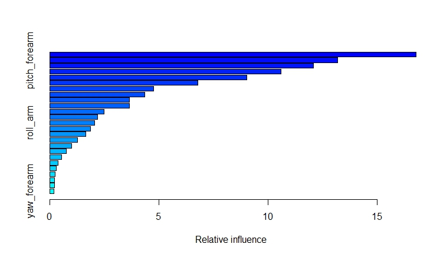

Both the training and test datasets were run with the prediction model and their outputs were compared to the *classe* variable for each observation.

```
Predictions Using Training and Test Data
-----------------------------------------

training.pred <- data.frame(predict(modFit.gbm,training), training$classe)
testing.pred <- data.frame(predict(modFit.gbm,testing), testing$classe)
names(training.pred) <- c("classe.pred", "classe.orig")
names(testing.pred) <- c("classe.pred", "classe.orig")
```

```
> summary(training.pred$classe.pred == training.pred$classe.orig)
   Mode   FALSE    TRUE    NA's
logical     626   13111       0
>
> summary(testing.pred$classe.pred == testing.pred$classe.orig)
   Mode   FALSE    TRUE    NA's
logical     364    5521       0
>
```

The graphs below show the performance of the tuning parameters

```
for(stat in c('Accuracy', 'Kappa')) {

  plot(modFit.gbm, metric=stat)
}
```

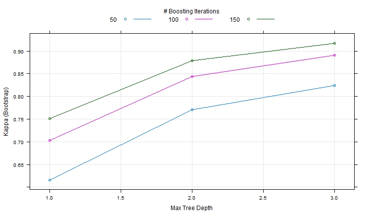

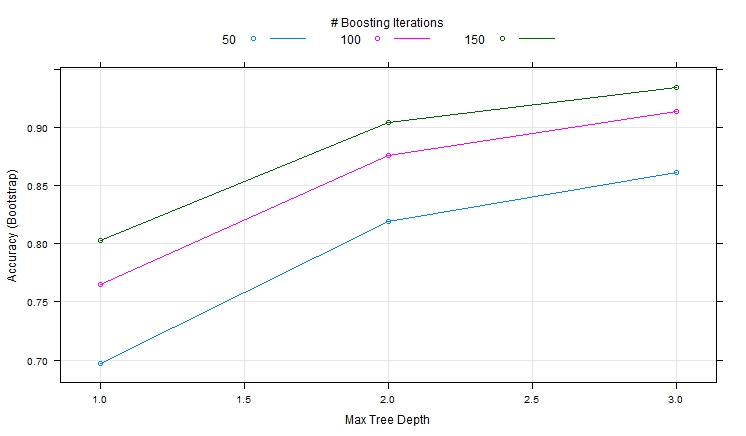